# Solver for problem posed on a tube

Try solving a steady PDEs posed on a 2D and 3D domains with fitted meshes:

- 2D domain is a a unit circle, with a S-type mesh on the boundary
- 3D domains is an extrusion of the 2D one

Solved with a standard Galerlin method. The values of $\varepsilon$, $f$ and $r$ are set below in the "PDE Data" section.

This code: Oct 2023, NM.

```python
import os
if "OMP_NUM_THREADS" not in os.environ:
    os.environ["OMP_NUM_THREADS"] = "1"

%matplotlib notebook
```

```python
from firedrake import *
import numpy as np

from mpl_toolkits.mplot3d import Axes3D
from matplotlib import cm
import matplotlib.pyplot as plt
from matplotlib.colors import ListedColormap
from matplotlib.tri import Triangulation

from MyMeshFunctions import *

import scipy.io
from firedrake.petsc import PETSc
from datetime import datetime

from firedrake.cython import dmcommon

## Suppress TSFC quadrature warnings
#import logging
#logger = logging.getLogger("tsfc")
#logger.setLevel(ERROR)
```

```python
comm = COMM_WORLD.Split(COMM_WORLD.rank % 2)
```

## Mesh functions

Most of the functions used are in `MyMeshfunctions.py`. Exception is `SUnitDishMeshHierarchy`: entirely based on Scott's code. .

```python
def SUnitDiskMeshHierarchy(tau, mesh_maker=MakeSMesh_isotropic, nref=0, meshorder=2):

    V, T = mesh_maker(tau)
    mh = MeshHierarchy(MakeTriMesh(V, T, comm), nref)

    if meshorder > 1:
        HOcoords = [ Function(VectorFunctionSpace(mesh, "CG", meshorder)).interpolate(mesh.coordinates) for mesh in mh ]
        HOmeshes = [mesh.Mesh(T) for T in HOcoords]

        mh = HierarchyBase(
            HOmeshes, mh.coarse_to_fine_cells,
            mh.fine_to_coarse_cells,
            refinements_per_level=mh.refinements_per_level, nested=mh.nested
        )


    for refinement_level, msh in enumerate(mh):
        coords = msh.coordinates.dat.data
        for x in coords:
            norm = np.sqrt(np.dot(x, x))
            if norm > 1. / (1 << (refinement_level + 1)):
                t = np.max(np.abs(x)) / norm
                x[:] *= t
    return mh
```

## 2D Solver, and error computations

```python
def Solve_2DRD(epsilon, r, f, mesh, degree):
    Ue = FiniteElement("CG", mesh.ufl_cell(), degree)
    V = FunctionSpace(mesh, Ue)

    (x,y) = SpatialCoordinate(mesh)
    rhs = f(x,y)
    reaction = r(x,y)
    u = TrialFunction(V)
    v = TestFunction(V)
    a = (epsilon**2)*inner(grad(u), grad(v))*dx + inner(reaction*u,v)*dx
    L = dot(rhs, v)*dx

    bc_u = DirichletBC(V, 0.0, "on_boundary")
    sol = Function(V)

    start = datetime.now()
    solve(a == L, sol, bcs=bc_u, solver_parameters=Solver_Params)
    uN = sol
    end = datetime.now()
    solve_time = (end-start).total_seconds() / 60
    return uN, V, solve_time
```

```python
def CompErrors(u2, uN):
    L2_ip  = assemble(inner(uN-u2, (uN-u2))*dx)
    H1_ip  = assemble(inner(grad(uN-u2), grad(uN-u2))*dx)
    energy_error = sqrt( float(epsilon)**2.0*H1_ip + L2_ip)
    Diff = interpolate(uN - u2, V)
    Diff_vec = np.abs(Diff.dat.data_ro)
    max_error  = Diff_vec.max()
    #print(f"l2={sqrt(L2_ip)}, h1={sqrt(H1_ip)} ee = {energy_error}, max={max_error}")
    return max_error, energy_error
```

## PDE Data

```python
epsilon = Constant(1.0e-2) # Place-holder for form compiler
r = lambda x,y : sqrt(2.0 + x/2.0 - y/2.0)
f = lambda x,y : exp(1.0 + x/2.0 + y/3.0)
print (f'epsilon = {epsilon}')
```

```
epsilon = [0.01]
```

## Discretization data

- Value of $N$ for which you want to solve
- sigma: relates to the mesh width (2 is good)

```python
N = 32
print(f"Solving for N={N}")
sigma = Constant(2.0) # mesh parameter (order of scheme+1)
b0 = Constant(0.99)   # b0^2 < b, where b is the coef of u
Solver_Params={ 'ksp_type': 'preonly', 'pc_type': 'lu',
               'pc_factor_mat_solver_type': 'mumps', 'mat_type': 'aij'}
```

```
Solving for N=32
```

### *IMPORTANT*

- Set `mesh_maker` to `MakeSMesh_isotropic1` to get a (quite) classical Shishkin mesh, with all triangles having SW-NE oriented edges.
- Set `mesh_maker` to `MakeSMesh_isotropic` to get a (somewhat) classical Shishkin mesh, with triangles in the corner regions that are very fine in both $x$ and $y$ directions.
- Set `mesh_maker` to `MakeSMesh_anisotropic` to get a non-standard classical Shishkin mesh, with only ansotropic meshes in the layer regions.
- Set `mesh_maker` to `MakeSMesh_anisotropic_old` to get a non-standard classical Shishkin mesh that appears to lead to crossing. If you do, need to change how the transition point is calculated, and also now the number of levels of refinement is selected.

```python
mesh_maker=MakeSMesh_anisotropic # I've other code where we can make other meshes
```

## Run Tests

```python
ref_level = np.int32(np.log2(N/3)-1)
tau = np.min([.25, float(sigma*epsilon)*np.log(N)])
print(f"epsilon={float(epsilon):3.2e}, tau={tau:.4e}")
Mesh2D = SUnitDiskMeshHierarchy(tau, mesh_maker, ref_level, meshorder=2)[-1]

uN,V,time = Solve_2DRD(epsilon, r, f, Mesh2D, 1)
u2,V2,time2 = Solve_2DRD(epsilon, r, f, Mesh2D, 2)
max_error, energy_error = CompErrors(u2, uN)
print(f"N: {N:4d} eps={float(epsilon):.1e} Errors: energy={energy_error:8.4e}, max={max_error:8.4e} (times={time:.2f}s,{time2:.2f})")
```

```
epsilon=1.00e-02, tau=6.9315e-02
N:   32 eps=1.0e-02 Errors: energy=2.3173e-01, max=6.3620e-01 (times=0.00s,0.00)
```

## Plot solution

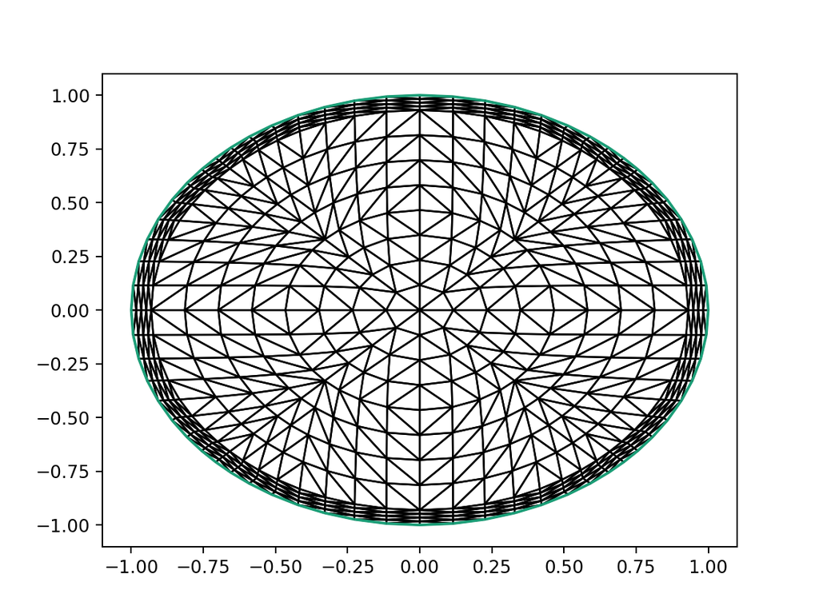

```python
fig1, axes1 = plt.subplots()
triplot( Mesh2D, axes=axes1)

File("uN.pvd").write(uN) # view with paraview
```

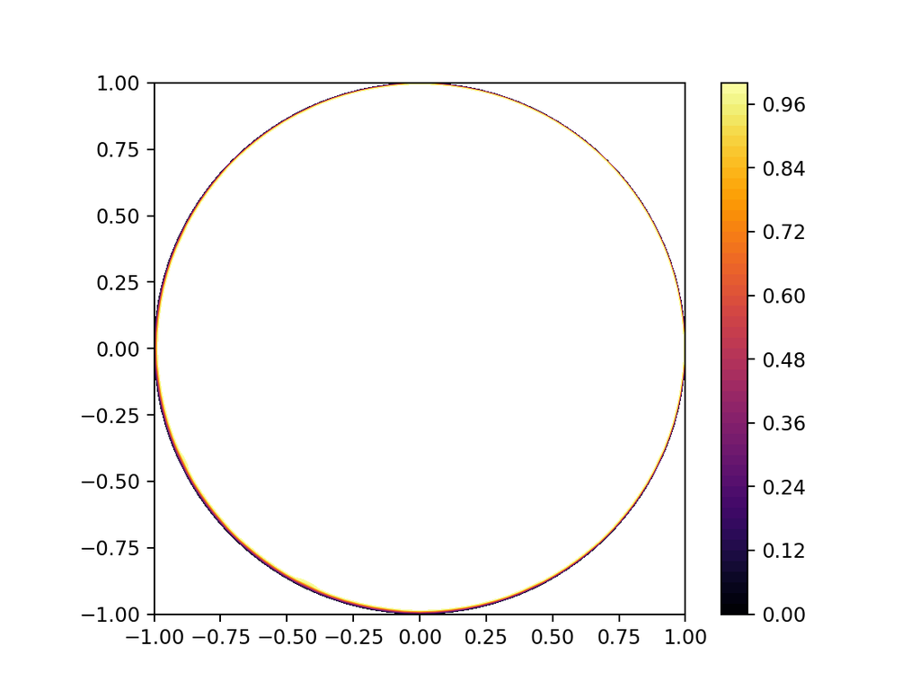

```python
fig2, axes2 = plt.subplots()
levels = np.linspace(0, 1, 51)
contours = tricontourf(uN, levels=levels, axes=axes2, cmap="inferno")
axes2.set_aspect("equal")
fig2.colorbar(contours)
```

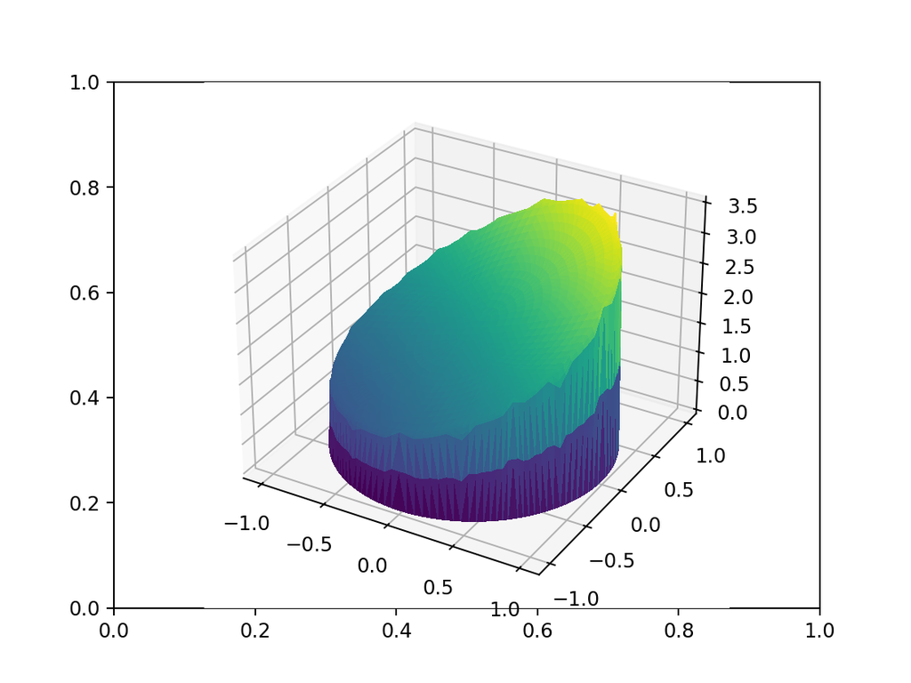

```python
fig3, axes3 = plt.subplots()
axes3 = fig3.add_subplot(111, projection='3d')
trisurf(uN, axes=axes3)
```

## 3D problem

- Domain: a cylinder of height (in $z$) of 10, with 2D circle mesh from above in (x,y).
- PDE: $-\varepsilon^2 \Delta u + u(x,y,z) = 3+x+y$ with homogenious boundary conditions on the curved edges, and Neumann at $z=0$ and $z=10$.

```python
Mesh3D = ExtrudedMesh(Mesh2D, 20, layer_height=0.5, extrusion_type='uniform')
File("Mesh3D.pvd").write(Mesh3D) # view with paraview
```

```python
horiz_elt = FiniteElement("CG", triangle, 1)
vert_elt = FiniteElement("CG", interval, 1)
elt = TensorProductElement(horiz_elt, vert_elt)
V = FunctionSpace(Mesh3D, elt)
```

```python
(x,y,z) = SpatialCoordinate(Mesh3D)

f = 3+x+y
r = 1.0+x-x+y-y+z-z
u = TrialFunction(V)
v = TestFunction(V)
a = (epsilon**2)*inner(grad(u), grad(v))*dx + inner(r*u,v)*dx
L = dot(f, v)*dx

BC_side = DirichletBC(V, 0.0, "on_boundary") # Dirichlet only on sides!

u3D = Function(V)
solve(a == L, u3D, bcs=BC_side, solver_parameters=Solver_Params)
```

Check if we get sensible values at certain points

```python
File("u3D.pvd").write(u3D) # view with paraview
```

```python
print(f"u3D(0.0,0.0,0.0)={u3D.at((0.0,0.0,0.0))}")
print(f"u3D(0.1,0.2,5.0)={u3D.at((0.1,0.2,5.0))}")
print(f"u3D(-.1,-0.3,10.0)={u3D.at((-.1,-0.3,10.0))}")
```

```
u3D(0.0,0.0,0.0)=2.999999991583752
u3D(0.1,0.2,5.0)=3.303261304282804
u3D(-.1,-0.3,10.0)=2.5989642787079075
```

```python
from IPython.display import Image
from IPython.core.display import HTML
Image(url= "https://www.niallmadden.ie/private/Nanda/Tube.png", width=500)
```

[figure not shown]